# Logistic Regression: Script Lecture 5

Michaela Kreyenfeld (in collaboration with Cristina Samper)

Fall 2019

# 1 Interaction Models

## 1.1 Interaction Models in OLS Regression

You may already be familiar with interaction models from OLS regression. Therefore, let’s start with a classic example where the dependent variable is ‘monthly earnings’. Model 1 in Table 1 provides you with the model results of a standard model that controls for age (as a continuous covariate) and for gender (as a binary). Figure 1a plots the estimated curves for women and men. It shows that the age-earning profile of women and men is the same. From labor market literature we know that this is not the case. However, the OLS model, which is an additive model, forces the data into this shape. We may, however, relax this assumption.

One option could be that we run **separate models** for women and men. When we estimate separate models, we will automatically get different estimates for age for the different sexes. However, separate models are usually not recommended. Firstly, they “waste” parameters. The second, probably more important reason is that it is difficult to compare coefficients and significance levels across models.

An interaction model is the more efficient strategy. In OLS regression, one usually runs an interaction model by including the covariate of interest plus a multiplicative term of the two covariates that are to be interacted. The latter is usually called the **interaction effect** ($b_3$ the coefficient of $x_1x_2$ in Model 2), while the first are usually denoted as the **main effect** ($b_1$ and $b_2$ the coefficients of $x_1$ and $x_2$).

$x_1$=Age and $x_2$=Gender

Model 1: $Monthly\_earnings = b_0 + b_1x_1 + b_2x_2$

Model 2: $Monthly\_earnings = b_0 + b_1x_1 + b_2x_2 + b_3x_1x_2$

In Table 1, Model 2, gives the results of an interaction of age and gender. Figure 1b plots the model that includes the interaction effect. Now, the slope for women and men is different!

```r
ISSP2012_G02$Gender <- relevel(ISSP2012_G02$Gender, ref="male")

model_1 <- lm(DEP ~ AGE + Gender, data=ISSP2012_G02)
model_2 <- lm(DEP ~ AGE * Gender, data=ISSP2012_G02)

covlabels <- c("Age (Continuous)", "Gender: Female", "Gender: Female*Age")
collabels <- c("Model 1", "Model 2")
```

**Table 1**: Results from OLS Regression

```r
stargazer(model_1, model_2, single.row=F, type="html", covariate.labels=covlabels, column.labels = collabels)
```

|  | *Dependent variable:* |  |
| --- | --- | --- |
|  | DEP |  |
|  | Model 1 | Model 2 |
|  | (1) | (2) |
| Age (Continuous) | 21.068*** | 32.354*** |
|  | (2.975) | (4.105) |
| Gender: Female | -718.268*** | 237.314 |
|  | (71.414) | (251.478) |
| Gender: Female*Age |  | -23.417*** |
|  |  | (5.913) |
| Constant | 1,069.354*** | 607.438*** |
|  | (131.846) | (175.334) |
| Observations | 1,036 | 1,036 |
| R<sup>2</sup> | 0.129 | 0.142 |
| Adjusted R<sup>2</sup> | 0.127 | 0.139 |
| Residual Std. Error | 1,149.241 (df = 1033) | 1,141.157 (df = 1032) |
| F Statistic | 76.355*** (df = 2; 1033) | 56.856*** (df = 3; 1032) |
| *Note:* | *p<0.1; **p<0.05;*** p<0.01 |  |

**Figure 1a:** Predicted values from OLS Model (Model 1)

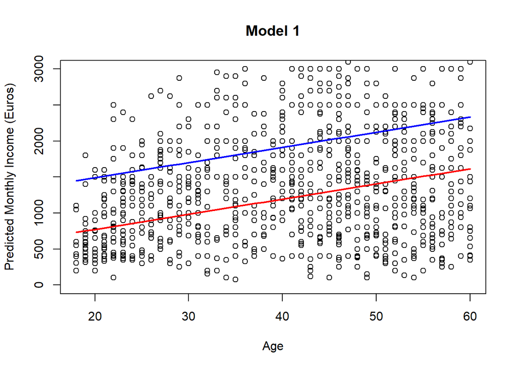

**Figure 1b:** Predicted values from OLS Model (Model 2)

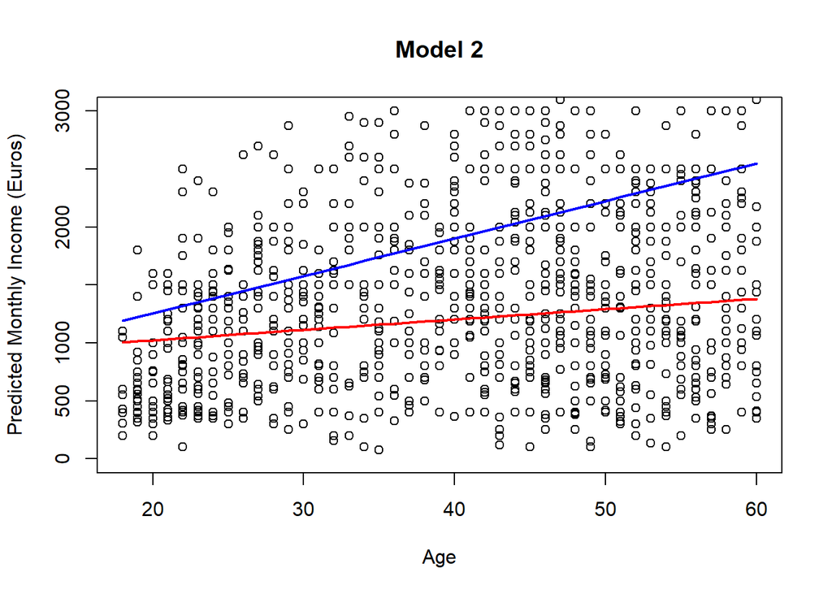

## 1.2 Interaction Models in Logistic Regression (with R examples)

Interaction models in logistic regression follow a similar logic as interaction models in OLS regressions. However, the results are more difficult to interpret. It is particularly difficult to correctly interpret interaction models with continuous variables. Wrong interpretations of this type of interactions have in the past led to some confusion (Aia and Norton 2003). However, interpreting interaction effects of categorical covariates is rather straightforward.

### 1.2.1 Manual Version (same as ‘:’ version)

Imagine that you are interested in religiosity in a population. The outcome variable is a binary variable (0: not religious, 1: religious). You are interested in the effect of age (0: young and 1: old) and education (0: low education and 1: high education) on religiosity. The easiest way of estimating an interaction model is to generate a new variable that captures all different combinations of your two variable of interest, which are:

- 1: Education low & young
- 2: Education low & old
- 3: Education high & young
- 4: Education high & old

You may then include this newly created variable into your model. The code and the R-output in OR form is as follows:

```r
SUBSET02$INT <- -1
SUBSET02$INT[SUBSET02$EDU_C=="0-low" & SUBSET02$AGE_C=="0-young"] <- "1-low & young"
SUBSET02$INT[SUBSET02$EDU_C=="0-low" & SUBSET02$AGE_C=="1-old"] <- "2-low & old"
SUBSET02$INT[SUBSET02$EDU_C=="1-high" & SUBSET02$AGE_C=="0-young"] <- "3-high & young"
SUBSET02$INT[SUBSET02$EDU_C=="1-high" & SUBSET02$AGE_C=="1-old"] <- "4-high & old"
SUBSET02$INT <- factor(SUBSET02$INT)

model_int1 <- glm(DEP~ INT, data=SUBSET02, family=binomial())
# Ignore p-values
exp(summary(model_int1)$coefficients)
```

```
##                    Estimate Std. Error      z value Pr(>|z|)
## (Intercept)       0.2010960   1.017813 3.514955e-40 1.000000
## INT2-low & old    1.1795921   1.025443 7.161722e+02 1.000000
## INT3-high & young 0.6517741   1.038086 1.062977e-05 1.000000
## INT4-high & old   0.9571778   1.044497 3.659395e-01 1.369928
```

In order to better understand the results from the interaction model, I have inserted the model results into a table (Table 2).

**Table 2**: Results from Interaction Model, Odds Ratios, Interaction of Age and Education, Dependent Variable: Religiosity (binary variable 0/1) Education

|  | Edu:Low | Edu:High |
| --- | --- | --- |
| Young age | 1.00 | 0.65 |
| Old age | 1.18 | 0.96 |

An interaction model is very rich and provides a lot of information and perspectives. You may read the table row and column wise. Let’s start with the rows:

- Highly educated youngsters have a 35% lower odds of being religious than lowly educated youngsters.
- For older age groups, the effect is similar but smaller. Here, lower educated respondents have 23% (1.18/.96=1.229) higher odds compared to higher educated “oldies”.

Now let’s turn to the columns:

- For the lowly educated, religiosity increases with age. Among this group, old respondents have odds that are elevated by the factor 1.18.
- For the highly educated, it also increases with age but much more strongly. Religiosity increases with age 48% (.96/.65=1.476).

You may also want to make a graph of the results from the interaction (see Figure 2), to give you an immediate insight into the question of whether the effect of education is different depending on age.

Please note, however, this “interaction solution” has one drawback. The level of significance of the parameter refers to the difference from the reference category. It does not provide an overall assessment whether the interaction is significant or not.

This is the code to graph the interaction in `model_int1`

```r
library(ggplot2)

# Extract coefficients from the model and create a data frame to put in all the information
TEST01<-model_int1$coefficients
TEST02<-data.frame(TEST01)
TEST02$OR <- exp(TEST01)
# Extract the confidence intervals and exponentiate them, then rename them so it's easier to use them when graphing
CONFINT <- data.frame(exp(confint(model_int1)))
names(CONFINT)<-c("L", "U")
# Bind together the confidence intervals and the OR
TEST03 <- cbind(TEST02, CONFINT)
# This is how the data frame looks:
head(TEST03)
```

```
##                       TEST01        OR         L         U
## (Intercept)       -1.6039727 0.2010960 0.1942301 0.2081493
## INT2-low & old     0.1651687 1.1795921 1.1229119 1.2391376
## INT3-high & young -0.4280573 0.6517741 0.6054932 0.7010512
## INT4-high & old   -0.0437661 0.9571778 0.8783952 1.0418738
```

```r
# remove the intercept or any rows that you don't want to include in the graph
# When you have the '[a,b]' a refers to the row numbers and b refers to the columns
TEST04 <- TEST03[-c(1),]
# Now you can add an extra row manually to have the reference category (all the entries are 1)
TEST04[nrow(TEST04)+1,] <- 1
# insert the labels as a new column in the order of your data frame (ALWAYS CHECK they are in the right order)
TEST04$Labels = c("low:old", "high:young", "high:old", "low:young")
TEST04$Labels <-factor(TEST04$Labels)
# Organize the levels how you would like to graph them
levels(TEST04$Labels)
```

```
## [1] "high:old"   "high:young" "low:old"    "low:young"
```

```r
# To reorder insert in `c()` the new desired order (I want to see young vs. old)
TEST04$Labels = factor(TEST04$Labels, levels(TEST04$Labels)[c(4,2,3,1)])
```

```r
ggplot(data=TEST04, aes(x=Labels, y=OR, fill=Labels)) +
  geom_bar(stat="identity")+
  geom_errorbar(aes(ymin=L, ymax=U), width=.1) +
  scale_fill_manual("Categories", values = c("red", "blue", "red", "blue"))+
  theme(legend.position = "none") +
  xlab("Age x Education")
```

**Figure 2:** Odds Ratios from Interaction Model

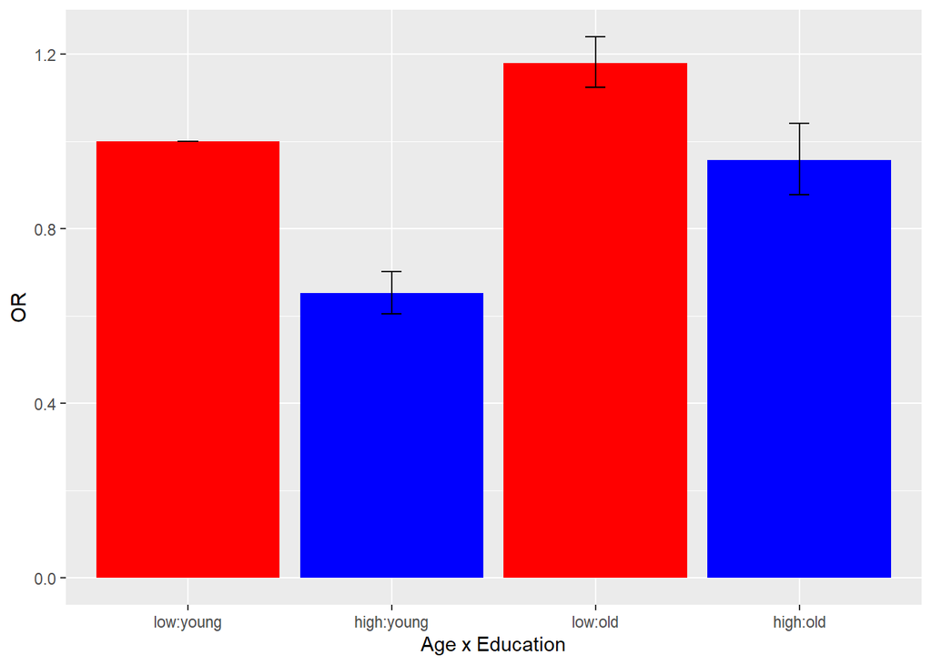

Note that there are no confidence intervals around the category ‘low: young’ this is because it is the reference category.

### 1.2.2 ‘:’ version

Instead of constructing your own “interaction” variable, you may ask R to do it. You simply insert a colon (:) between the two variables that you want to interact. The results are exactly the same as in the “manual version” (see above).

```r
SUBSET02$INT <- SUBSET02$EDU_C:SUBSET02$AGE_C
model_int <- glm(DEP~ INT, data=SUBSET02, family=binomial())
exp(model_int$coefficients)
```

```
##       (Intercept)    INT0-low:1-old INT1-high:0-young   INT1-high:1-old
##         0.2010960         1.1795921         0.6517741         0.9571778
```

You can also enter it directly in the model, but you might need to relevel to obtain the reference category that you wish.

```r
# In this case it took automatically the category '1-high:1-old' as a reference category
model_int <- glm(DEP~ EDU_C:AGE_C, data=SUBSET02, family=binomial())

exp(model_int$coefficients)
```

```
##              (Intercept)  EDU_C0-low:AGE_C0-young EDU_C1-high:AGE_C0-young
##                0.1924847                1.0447380                0.6809331
##    EDU_C0-low:AGE_C1-old   EDU_C1-high:AGE_C1-old
##                1.2323647                       NA
```

```r
# If you 'relevel' the interaction, you obtain the same results as the 'manual' version
model_int <- glm(DEP~ relevel(SUBSET02$EDU_C:SUBSET02$AGE_C, ref="0-low:0-young"), data=SUBSET02, family=binomial())

exp(model_int$coefficients)
```

```
##                                                                 (Intercept)
##                                                                   0.2010960
##    relevel(SUBSET02$EDU_C:SUBSET02$AGE_C, ref = "0-low:0-young")0-low:1-old
##                                                                   1.1795921
## relevel(SUBSET02$EDU_C:SUBSET02$AGE_C, ref = "0-low:0-young")1-high:0-young
##                                                                   0.6517741
##   relevel(SUBSET02$EDU_C:SUBSET02$AGE_C, ref = "0-low:0-young")1-high:1-old
##                                                                   0.9571778
```

### 1.2.3 ’*’ version

Apart from these simple solutions, there is also the possibility to include a main and an interaction effect like you are used to from OLS regression. You only need to insert an asterisk (*) between the two variables that you want to interact with each other. Do NOT additionally add the respective variables. R will do that automatically (which is e.g. different from SPSS).

```r
model_int2 <- glm(DEP~ EDU_C*AGE_C, data=SUBSET02, family=binomial())

coef(model_int2)
```

```
##            (Intercept)            EDU_C1-high             AGE_C1-old
##             -1.6039727             -0.4280573              0.1651687
## EDU_C1-high:AGE_C1-old
##              0.2191225
```

```r
exp(coef(model_int2))
```

```
##            (Intercept)            EDU_C1-high             AGE_C1-old
##              0.2010960              0.6517741              1.1795921
## EDU_C1-high:AGE_C1-old
##              1.2449837
```

However, the interaction effect is rather difficult to interpret. Different from the OLS model, where the interaction effect just gives the additive effect of a certain combination, the interaction effect in the logistic regression gives the multiplicative effect. However, both “interaction versions” are closely related as can be seen below:

**Results:** (*)-version

```r
exp(coef(model_int2))
```

```
##            (Intercept)            EDU_C1-high             AGE_C1-old
##              0.2010960              0.6517741              1.1795921
## EDU_C1-high:AGE_C1-old
##              1.2449837
```

**Results:** (:)-version

```r
exp(coef(model_int1))
```

```
##       (Intercept)    INT2-low & old INT3-high & young   INT4-high & old
##         0.2010960         1.1795921         0.6517741         0.9571778
```

Notice that in the (*)-version, the OR coefficient for `AGE_C1-old` (1.18) is the same as the coefficient of `INT2-low & old` in the (:)-version. Also the OR coefficient for `EDU_C1-high` (.652) is the same as the coefficient of `INT3-high & young` in the (:)-version.

To obtain the same coefficient for `INT4-high & old` that you get in the (:)-version, from the (*)-version, you must however multiply all the OR coefficients in the interaction including the interaction term:

```r
.6518*1.1796*1.245
```

```
## [1] 0.9572348
```

`.957` is the same as the OR coefficient for the `INT4-high & old` category in the (:)-version.

#Acknowledgment Thanks to Lena Klein for language editing. For comments on an earlier version, I thank Florien Kruse. All remaining errors are my own. (I am always happy to receive comments and suggestions on this document: kreyenfeld@hertie-school.org)

#References Aia, C., & Nortonb, E. C. (2003). Interaction terms in logit and probit models. *Economics Letters*, 80, 123–129.